# Hickman Homework 6

I found a kernel from Kaggle User AiO at: https://www.kaggle.com/notaapple/detailed-exploratory-data-analysis-using-r that has some interesting exploratory techniques that I will reproduce here.

```r
library(data.table)
```

```r
str(train)
```

```
Classes ‘data.table’ and 'data.frame':  1460 obs. of  81 variables:
 $ Id           : int  1 2 3 4 5 6 7 8 9 10 ...
 $ MSSubClass   : int  60 20 60 70 60 50 20 60 50 190 ...
 $ MSZoning     : chr  "RL" "RL" "RL" "RL" ...
 $ LotFrontage  : int  65 80 68 60 84 85 75 NA 51 50 ...
 $ LotArea      : int  8450 9600 11250 9550 14260 14115 10084 10382 6120 7420 ...
 $ Street       : chr  "Pave" "Pave" "Pave" "Pave" ...
 $ Alley        : chr  NA NA NA NA ...
 $ LotShape     : chr  "Reg" "Reg" "IR1" "IR1" ...
 $ LandContour  : chr  "Lvl" "Lvl" "Lvl" "Lvl" ...
 $ Utilities    : chr  "AllPub" "AllPub" "AllPub" "AllPub" ...
 $ LotConfig    : chr  "Inside" "FR2" "Inside" "Corner" ...
 $ LandSlope    : chr  "Gtl" "Gtl" "Gtl" "Gtl" ...
 $ Neighborhood : chr  "CollgCr" "Veenker" "CollgCr" "Crawfor" ...
 $ Condition1   : chr  "Norm" "Feedr" "Norm" "Norm" ...
```

[output cut: 68 more lines]

The train dataset has 1460 observations of 81 variables, with the 81st variable being the target (not included in test dataset); Sale Price. There are several apparently discrete variables that are categorized as continuous, as noted below. Roughly half of the 81 variables are continuous, so we have a dataset that will lend itself well to regression analysis. With the relatively high number of variables, we may want to reduce dimensionality with PCA as well. First, I need to understand and correctly name the variables.

```r
summary(train)
```

```
       Id           MSSubClass      MSZoning          LotFrontage
 Min.   :   1.0   Min.   : 20.0   Length:1460        Min.   : 21.00
 1st Qu.: 365.8   1st Qu.: 20.0   Class :character   1st Qu.: 59.00
 Median : 730.5   Median : 50.0   Mode  :character   Median : 69.00
 Mean   : 730.5   Mean   : 56.9                      Mean   : 70.05
 3rd Qu.:1095.2   3rd Qu.: 70.0                      3rd Qu.: 80.00
 Max.   :1460.0   Max.   :190.0                      Max.   :313.00
                                                     NA's   :259
    LotArea          Street             Alley             LotShape
 Min.   :  1300   Length:1460        Length:1460        Length:1460
 1st Qu.:  7554   Class :character   Class :character   Class :character
 Median :  9478   Mode  :character   Mode  :character   Mode  :character
 Mean   : 10517
 3rd Qu.: 11602
 Max.   :215245

 LandContour         Utilities          LotConfig          LandSlope
 Length:1460        Length:1460        Length:1460        Length:1460
 Class :character   Class :character   Class :character   Class :character
 Mode  :character   Mode  :character   Mode  :character   Mode  :character




 Neighborhood        Condition1         Condition2          BldgType
 Length:1460        Length:1460        Length:1460        Length:1460
 Class :character   Class :character   Class :character   Class :character
 Mode  :character   Mode  :character   Mode  :character   Mode  :character




  HouseStyle         OverallQual      OverallCond      YearBuilt     YearRemodAdd
 Length:1460        Min.   : 1.000   Min.   :1.000   Min.   :1872   Min.   :1950
 Class :character   1st Qu.: 5.000   1st Qu.:5.000   1st Qu.:1954   1st Qu.:1967
 Mode  :character   Median : 6.000   Median :5.000   Median :1973   Median :1994
                    Mean   : 6.099   Mean   :5.575   Mean   :1971   Mean   :1985
                    3rd Qu.: 7.000   3rd Qu.:6.000   3rd Qu.:2000   3rd Qu.:2004
                    Max.   :10.000   Max.   :9.000   Max.   :2010   Max.   :2010

```

[output cut: 104 more lines]

```
    Fence           MiscFeature           MiscVal             MoSold
 Length:1460        Length:1460        Min.   :    0.00   Min.   : 1.000
 Class :character   Class :character   1st Qu.:    0.00   1st Qu.: 5.000
 Mode  :character   Mode  :character   Median :    0.00   Median : 6.000
                                       Mean   :   43.49   Mean   : 6.322
                                       3rd Qu.:    0.00   3rd Qu.: 8.000
                                       Max.   :15500.00   Max.   :12.000

     YrSold       SaleType         SaleCondition        SalePrice
 Min.   :2006   Length:1460        Length:1460        Min.   : 34900
 1st Qu.:2007   Class :character   Class :character   1st Qu.:129975
 Median :2008   Mode  :character   Mode  :character   Median :163000
 Mean   :2008                                         Mean   :180921
 3rd Qu.:2009                                         3rd Qu.:214000
 Max.   :2010                                         Max.   :755000
```

*I’m 100% sure there is an easier way to do this - possibly with an sapply or c() function.*

Now that the datatypes are set, we can move on with our analysis. I found an interesting method to separate continuous and discrete variables on Kaggle:

```r
numeric_var
```

```
 [1] "Id"            "MSSubClass"    "LotFrontage"   "LotArea"       "OverallQual"
 [6] "OverallCond"   "YearBuilt"     "YearRemodAdd"  "MasVnrArea"    "BsmtFinSF1"
[11] "BsmtFinSF2"    "BsmtUnfSF"     "TotalBsmtSF"   "1stFlrSF"      "2ndFlrSF"
[16] "LowQualFinSF"  "GrLivArea"     "BsmtFullBath"  "BsmtHalfBath"  "FullBath"
[21] "HalfBath"      "BedroomAbvGr"  "KitchenAbvGr"  "TotRmsAbvGrd"  "Fireplaces"
[26] "GarageYrBlt"   "GarageCars"    "GarageArea"    "WoodDeckSF"    "OpenPorchSF"
[31] "EnclosedPorch" "3SsnPorch"     "ScreenPorch"   "PoolArea"      "MiscVal"
[36] "MoSold"        "YrSold"        "SalePrice"
```

# Missing features in the Data

At first impression, there appear to be several variables with many missing values. However, several of them are not necessarily missing, only listed as “NA” when the true value should be “none”. For instance, “Alley”; “NA”" might mean that we don’t have an alley, not that the values are missing. I’ll refactor this and other variables so that “NA” becomes None.

Found a good Analysis/transformation of variables from a Kaggle user here: https://www.kaggle.com/sidraina89/regularized-regression-housing-pricing

|  | index | Missing_Values |
| --- | --- | --- |
| MSZoning | MSZoning | 4 |
| LotFrontage | LotFrontage | 227 |
| Alley | Alley | 1352 |
| Utilities | Utilities | 2 |
| Exterior1st | Exterior1st | 1 |
| Exterior2nd | Exterior2nd | 1 |
| MasVnrType | MasVnrType | 16 |
| MasVnrArea | MasVnrArea | 15 |
| BsmtQual | BsmtQual | 44 |
| BsmtCond | BsmtCond | 45 |

[output cut: 23 more lines]

Immediately, several variables stand out that strongly suggest “NA” does not always mean “missing”. Additionally, the dataset description points to this conclusion. Alley, PoolQC, Fence, and MiscFeature all have a high number of NAs, but it’s also very probable that a high number of homes in our dataset don’t have those features at all. Let’s refactor those variables from “NA” to none:

```r
table(train$Alley)
```

```
Grvl None Pave
  70 1352   37
```

It worked! I understand I’ll have to do this same method on the test dataset as well. There were a few Kagglers who combined the two datasets to do the transform, but I don’t want to do that for quality reasons - I’ll do it the longer way.

```r
table(train$GarageQual)
```

```
  Fa   Gd None   Po   TA
  76   10   78    2 1293
```

Surprisingly, there are 9 homes listed with 0 full baths. Based on the other characteristics of the rows, these look like they might be missing rather than 0.

Many of the variables are right or left-skewed anyway.

```r
summary(train.numeric)
```

```
       Id           MSSubClass     LotFrontage        LotArea
 Min.   :   1.0   Min.   : 20.0   Min.   : 21.00   Min.   :  1300
 1st Qu.: 365.8   1st Qu.: 20.0   1st Qu.: 59.00   1st Qu.:  7554
 Median : 730.5   Median : 50.0   Median : 69.00   Median :  9478
 Mean   : 730.5   Mean   : 56.9   Mean   : 70.05   Mean   : 10517
 3rd Qu.:1095.2   3rd Qu.: 70.0   3rd Qu.: 80.00   3rd Qu.: 11602
 Max.   :1460.0   Max.   :190.0   Max.   :313.00   Max.   :215245
                                  NA's   :259
  OverallQual      OverallCond      YearBuilt     YearRemodAdd    MasVnrArea
 Min.   : 1.000   Min.   :1.000   Min.   :1872   Min.   :1950   Min.   :   0.0
 1st Qu.: 5.000   1st Qu.:5.000   1st Qu.:1954   1st Qu.:1967   1st Qu.:   0.0
 Median : 6.000   Median :5.000   Median :1973   Median :1994   Median :   0.0
 Mean   : 6.099   Mean   :5.575   Mean   :1971   Mean   :1985   Mean   : 103.7
 3rd Qu.: 7.000   3rd Qu.:6.000   3rd Qu.:2000   3rd Qu.:2004   3rd Qu.: 166.0
 Max.   :10.000   Max.   :9.000   Max.   :2010   Max.   :2010   Max.   :1600.0
                                                                NA's   :8
   BsmtFinSF1       BsmtFinSF2        BsmtUnfSF       TotalBsmtSF
 Min.   :   0.0   Min.   :   0.00   Min.   :   0.0   Min.   :   0.0
 1st Qu.:   0.0   1st Qu.:   0.00   1st Qu.: 223.0   1st Qu.: 795.8
 Median : 383.5   Median :   0.00   Median : 477.5   Median : 991.5
 Mean   : 443.6   Mean   :  46.55   Mean   : 567.2   Mean   :1057.4
 3rd Qu.: 712.2   3rd Qu.:   0.00   3rd Qu.: 808.0   3rd Qu.:1298.2
 Max.   :5644.0   Max.   :1474.00   Max.   :2336.0   Max.   :6110.0

    1stFlrSF       2ndFlrSF     LowQualFinSF       GrLivArea     BsmtFullBath
 Min.   : 334   Min.   :   0   Min.   :  0.000   Min.   : 334   Min.   :0.0000
 1st Qu.: 882   1st Qu.:   0   1st Qu.:  0.000   1st Qu.:1130   1st Qu.:0.0000
 Median :1087   Median :   0   Median :  0.000   Median :1464   Median :0.0000
 Mean   :1163   Mean   : 347   Mean   :  5.845   Mean   :1515   Mean   :0.4253
 3rd Qu.:1391   3rd Qu.: 728   3rd Qu.:  0.000   3rd Qu.:1777   3rd Qu.:1.0000
 Max.   :4692   Max.   :2065   Max.   :572.000   Max.   :5642   Max.   :3.0000

  BsmtHalfBath        FullBath        HalfBath       BedroomAbvGr    KitchenAbvGr
 Min.   :0.00000   Min.   :0.000   Min.   :0.0000   Min.   :0.000   Min.   :0.000
 1st Qu.:0.00000   1st Qu.:1.000   1st Qu.:0.0000   1st Qu.:2.000   1st Qu.:1.000
 Median :0.00000   Median :2.000   Median :0.0000   Median :3.000   Median :1.000
 Mean   :0.05753   Mean   :1.565   Mean   :0.3829   Mean   :2.866   Mean   :1.047
 3rd Qu.:0.00000   3rd Qu.:2.000   3rd Qu.:1.0000   3rd Qu.:3.000   3rd Qu.:1.000
 Max.   :2.00000   Max.   :3.000   Max.   :2.0000   Max.   :8.000   Max.   :3.000

```

[output cut: 16 more lines]

```
  ScreenPorch        PoolArea          MiscVal             MoSold
 Min.   :  0.00   Min.   :  0.000   Min.   :    0.00   Min.   : 1.000
 1st Qu.:  0.00   1st Qu.:  0.000   1st Qu.:    0.00   1st Qu.: 5.000
 Median :  0.00   Median :  0.000   Median :    0.00   Median : 6.000
 Mean   : 15.06   Mean   :  2.759   Mean   :   43.49   Mean   : 6.322
 3rd Qu.:  0.00   3rd Qu.:  0.000   3rd Qu.:    0.00   3rd Qu.: 8.000
 Max.   :480.00   Max.   :738.000   Max.   :15500.00   Max.   :12.000

     YrSold       SalePrice
 Min.   :2006   Min.   : 34900
 1st Qu.:2007   1st Qu.:129975
 Median :2008   Median :163000
 Mean   :2008   Mean   :180921
 3rd Qu.:2009   3rd Qu.:214000
 Max.   :2010   Max.   :755000
```

We’ll likely have to log transform the sale price variable to fit it to a linear regression model. The variable is right-skewed.

Running an initial linear model:

```r
summary(lm.sales)
```

```
Call:
lm(formula = SalePrice ~ ., data = train.numeric)

Residuals:
    Min      1Q  Median      3Q     Max
-442182  -16955   -2824   15125  318183

Coefficients: (2 not defined because of singularities)
                Estimate Std. Error t value Pr(>|t|)
(Intercept)   -3.351e+05  1.701e+06  -0.197 0.843909
Id            -1.205e+00  2.658e+00  -0.453 0.650332
MSSubClass    -2.001e+02  3.451e+01  -5.797 8.84e-09 ***
LotFrontage   -1.160e+02  6.126e+01  -1.894 0.058503 .
LotArea        5.422e-01  1.575e-01   3.442 0.000599 ***
OverallQual    1.866e+04  1.482e+03  12.592  < 2e-16 ***
OverallCond    5.239e+03  1.368e+03   3.830 0.000135 ***
YearBuilt      3.164e+02  8.766e+01   3.610 0.000321 ***
YearRemodAdd   1.194e+02  8.668e+01   1.378 0.168607
MasVnrArea     3.141e+01  7.022e+00   4.473 8.54e-06 ***
BsmtFinSF1     1.736e+01  5.838e+00   2.973 0.003014 **
BsmtFinSF2     8.342e+00  8.766e+00   0.952 0.341532
BsmtUnfSF      5.005e+00  5.277e+00   0.948 0.343173
TotalBsmtSF           NA         NA      NA       NA
`1stFlrSF`     4.597e+01  7.360e+00   6.246 6.02e-10 ***
`2ndFlrSF`     4.663e+01  6.102e+00   7.641 4.72e-14 ***
LowQualFinSF   3.341e+01  2.794e+01   1.196 0.232009
GrLivArea             NA         NA      NA       NA
BsmtFullBath   9.043e+03  3.198e+03   2.828 0.004776 **
BsmtHalfBath   2.465e+03  5.073e+03   0.486 0.627135
FullBath       5.433e+03  3.531e+03   1.539 0.124182
HalfBath      -1.098e+03  3.321e+03  -0.331 0.740945
BedroomAbvGr  -1.022e+04  2.155e+03  -4.742 2.40e-06 ***
KitchenAbvGr  -2.202e+04  6.710e+03  -3.282 0.001063 **
TotRmsAbvGrd   5.464e+03  1.487e+03   3.674 0.000251 ***
Fireplaces     4.372e+03  2.189e+03   1.998 0.046020 *
GarageYrBlt   -4.728e+01  9.106e+01  -0.519 0.603742
GarageCars     1.685e+04  3.491e+03   4.827 1.58e-06 ***
GarageArea     6.274e+00  1.213e+01   0.517 0.605002
WoodDeckSF     2.144e+01  1.002e+01   2.139 0.032662 *
OpenPorchSF   -2.252e+00  1.949e+01  -0.116 0.907998
EnclosedPorch  7.295e+00  2.062e+01   0.354 0.723590
`3SsnPorch`    3.349e+01  3.758e+01   0.891 0.373163
ScreenPorch    5.805e+01  2.041e+01   2.844 0.004532 **
PoolArea      -6.052e+01  2.990e+01  -2.024 0.043204 *
MiscVal       -3.761e+00  6.960e+00  -0.540 0.589016
MoSold        -2.217e+02  4.229e+02  -0.524 0.600188
YrSold        -2.474e+02  8.458e+02  -0.293 0.769917
---
Signif. codes:  0 ‘***’ 0.001 ‘**’ 0.01 ‘*’ 0.05 ‘.’ 0.1 ‘ ’ 1

Residual standard error: 36800 on 1085 degrees of freedom
  (339 observations deleted due to missingness)
Multiple R-squared:  0.8096,    Adjusted R-squared:  0.8034
F-statistic: 131.8 on 35 and 1085 DF,  p-value: < 2.2e-16
```

Analysis of the Model:

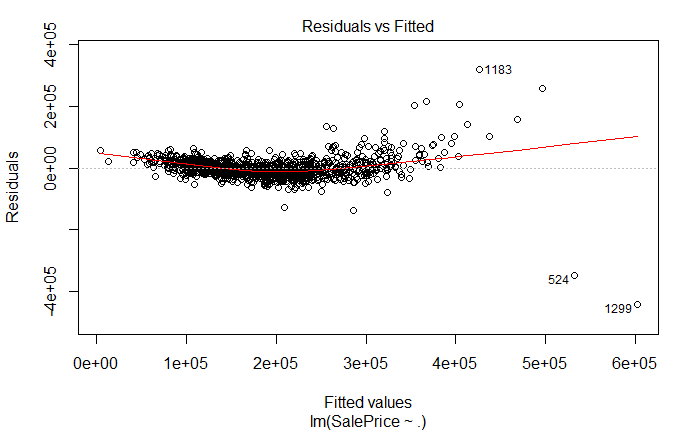

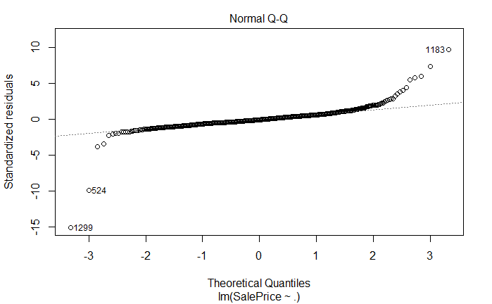

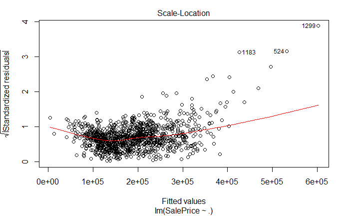

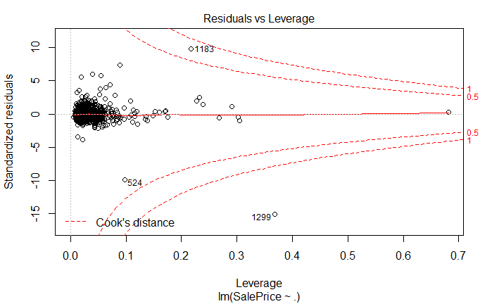

Given that we have so many variables that are skewed, I’d like to try a decision tree against the performance of our linear model. Additionally, given the presence of so many categorical variables, we might see better performance.

```r
summary(rt.sales)
```

```
Call:
rpart(formula = SalePrice ~ ., data = train)
  n= 1460

           CP nsplit rel error    xerror       xstd
1  0.45437625      0 1.0000000 1.0009530 0.07636356
2  0.12050238      1 0.5456237 0.5482382 0.04135060
3  0.06288535      2 0.4251214 0.4337272 0.04017400
4  0.03312902      3 0.3622360 0.3721520 0.02898495
5  0.02066528      4 0.3291070 0.3647093 0.03084560
6  0.01989959      5 0.3084417 0.3751301 0.03748753
7  0.01856908      6 0.2885421 0.3657048 0.03746918
8  0.01392462      7 0.2699730 0.3448485 0.03590503
9  0.01129700      8 0.2560484 0.3222177 0.03328921
10 0.01016483      9 0.2447514 0.3209704 0.03326613
11 0.01000000     10 0.2345866 0.3194643 0.03326344

Variable importance
 OverallQual Neighborhood   GarageCars  KitchenQual  TotalBsmtSF   GarageArea
          28           14            7            7            7            7
   GrLivArea    ExterQual    YearBuilt     BsmtQual   Foundation     2ndFlrSF
           5            4            4            4            3            2
TotRmsAbvGrd   HouseStyle     1stFlrSF BedroomAbvGr   BsmtFinSF1           Id
           2            1            1            1            1            1
  GarageType
           1

Node number 1: 1460 observations,    complexity param=0.4543763
  mean=180921.2, MSE=6.306789e+09
  left son=2 (1231 obs) right son=3 (229 obs)
  Primary splits:
      OverallQual  < 7.5     to the left,  improve=0.4543763, (0 missing)
      ExterQual    splits as  RLRL, improve=0.3786159, (0 missing)
      GarageCars   < 2.5     to the left,  improve=0.3650136, (0 missing)
      Neighborhood splits as  LLLLLLLLLLLLLRLRLLLLRRLRR, improve=0.3460826, (0 missing)
      GrLivArea    < 1488    to the left,  improve=0.3280228, (0 missing)
  Surrogate splits:
      Neighborhood splits as  LLLLLLLLLLLLLRLRLLLLLRLLL, agree=0.896, adj=0.336, (0 split)
      GarageCars   < 2.5     to the left,  agree=0.895, adj=0.332, (0 split)
      GarageArea   < 690.5   to the left,  agree=0.888, adj=0.288, (0 split)
```

[output cut: 164 more lines]

```

Node number 21: 287 observations
  mean=185210.3, MSE=7.858899e+08

Node number 22: 138 observations
  mean=217077.2, MSE=1.219806e+09

Node number 23: 30 observations
  mean=278706.2, MSE=1.979047e+09

Node number 30: 16 observations
  mean=402070.3, MSE=7.06213e+09

Node number 31: 10 observations
  mean=532083.9, MSE=2.97708e+10
```